# 1. Descripción del dataset

El conjunto de datos escogido para el desarrollo de esta práctica ha sido el que ofrece la plaforma Kaggle para su concurso titulado: [Titanic: Machine Learning from Disaster](https://www.kaggle.com/c/titanic/overview). Dicho dataset consiste en dos ficheros CSV, train y test, que contienen 12 y 11 columnas respectivamente. Cada registro representa a cada uno de los pasajeros que iban a bordo del Titanic de los cuales se nos indican las siguientes características:

- PassengerId: identificador único del pasajero.
- Survived: variable binaria que indica si el sujeto sobrevivió (1) o falleció (0). Dado que es el campo a estimar, este campo no está incluido en el test.
- Pclass: clase en la que viajaba el pasajero (1, 2 o 3).
- Name: nombre del pasajero.
- Sex: sexo del pasajero (male o female).
- Age: edad del pasajero.
- SibSp: número de hermanos/as o esposos/as a bordo del Titanic.
- Parch: número de padres o hijos/as a bordo del Titanic.
- Ticket: número del ticket del pasajero.
- Fare: tarifa pagada por el pasajero.
- Cabin: número de camarote asignado.
- Embarked: puerto en el que embarcó. C(Cherbourg), Q(Queenstown), S(Southampton).

Este conjunto de datos se pretende utilizar para esclarecer cuáles son las características (si las hubiese), que proporcionasen una mayor probabilidad de supervivencia a los pasajeros, o por el contrario una mayor probabilidad de no sobrevivir.

Carga de los datos:

```r
data<-read.csv("./train.csv",header=T,sep=",")
data$Pclass <- factor(data$Pclass, levels=c(1,2,3), labels=c("1ª class", "2ª class", "3ª class"))
data$Survived <- factor(data$Survived)
levels(data$Survived)[levels(data$Survived)=="0"] <- "Dead"
levels(data$Survived)[levels(data$Survived)=="1"] <- "Survived"
```

# 2. Selección de los datos

De los atributos mencionados en el apartado anterior, se ha determinado que hay varios que son irrelevantes para la pregunta que se quiere resolver.

- PassengetId: la identificación exacta del pasajero no es relevante.
- Name: la identificación exacta del pasajero no es relevante.
- Ticket: otra forma de identificar a los pasajeros, pero esta vez por grupos de individuos como familias que comparten el mismo número de ticket.
- Embarked: de las tablas abajo expuestas podemos deducir que dependiendo del puerto de partida es más probable que se viaje en una clase u en otra. Por ejemplo, el 93% pasajeros que parten desde Queenstown viajan en tercera clase y el 51% que lo hace desde Cherbourg lo hace en primera clase. Si bien es cierto que partir desde un puerto más rico aumenta las probabilidades de supervivencia del pasajero, esto está supeditado directamente por la clase en la que viaja, por lo que entendemos que este atributo es irrelevante.

```r
tabla <- table(droplevels(data$Embarked, exclude = ""),data$Survived)
prop.table(tabla, margin = 1)
```

```
##
##          Dead  Survived
##   C 0.4464286 0.5535714
##   Q 0.6103896 0.3896104
##   S 0.6630435 0.3369565
```

```r
tabla <- table(droplevels(data$Embarked, exclude = ""),data$Pclass)
prop.table(tabla, margin = 1)
```

```
##
##       1ª class   2ª class   3ª class
##   C 0.50595238 0.10119048 0.39285714
##   Q 0.02597403 0.03896104 0.93506494
##   S 0.19720497 0.25465839 0.54813665
```

- Fare: de la misma forma que el puerto de embarque, el precio pagado por el billete está supeditado con la clase en la que se viaja. Por lo que podemos considerar este atributo como irrelevante.

```r
data$Fare <- factor(cut(data$Fare, quantile(data$Fare), include.lowest = TRUE), labels = c("Low","Low/Mid","Mid/High","High"))

tabla <- table(data$Fare,data$Survived)
prop.table(tabla, margin = 1)
```

```
##
##                 Dead  Survived
##   Low      0.8026906 0.1973094
##   Low/Mid  0.6964286 0.3035714
##   Mid/High 0.5450450 0.4549550
##   High     0.4189189 0.5810811
```

```r
tabla <- table(data$Fare,data$Pclass)
prop.table(tabla, margin = 1)
```

```
##
##              1ª class   2ª class   3ª class
##   Low      0.02690583 0.02690583 0.94618834
##   Low/Mid  0.00000000 0.38392857 0.61607143
##   Mid/High 0.22972973 0.31531532 0.45495495
##   High     0.71621622 0.09909910 0.18468468
```

- SibSp: poco significativo para lo que se quiere responder.
- Parch: poco significativo para lo que se quiere responder.
- Cabin: más del 77% de los registros tienen este campo vacío, es difícil obtener utilidad de él.

```r
(nrow(data[data$Cabin == "",]) / nrow(data))*100
```

```
## [1] 77.10438
```

Se elimininan los atributos mencionados.

```r
data$PassengerId <- NULL
data$Name <- NULL
data$Ticket <- NULL
data$Embarked <- NULL
data$Fare <- NULL
data$SibSp <- NULL
data$Parch <- NULL
data$Cabin <- NULL
```

# 3. Limpieza de los datos

## 3.1 Valores perdidos

Antes de nada, lo primero será obtener un breve resumen estadístico del conjunto de datos.

```r
summary(data)
```

```
##      Survived        Pclass        Sex           Age
##  Dead    :549   1ª class:216   female:314   Min.   : 0.42
##  Survived:342   2ª class:184   male  :577   1st Qu.:20.12
##                 3ª class:491                Median :28.00
##                                             Mean   :29.70
##                                             3rd Qu.:38.00
##                                             Max.   :80.00
##                                             NA's   :177
```

En lo que se refiere a valores perdidos, se observa que el único campo que los contiene es el de la Edad (age). Para recuperar estos valores se utilizará la función kNN (k vecinos más próximos) del paquete VIM para estimar la edad en función de registros con características similares del que se queire estimar.

```r
library("VIM")
knnData<-kNN(data, k=3)
data$Age <- knnData$Age
summary(data)
```

```
##      Survived        Pclass        Sex           Age
##  Dead    :549   1ª class:216   female:314   Min.   : 0.42
##  Survived:342   2ª class:184   male  :577   1st Qu.:21.00
##                 3ª class:491                Median :26.00
##                                             Mean   :28.76
##                                             3rd Qu.:36.00
##                                             Max.   :80.00
```

## 3.2 Valores extremos

Los valores extremos, valores atípicos u outliers, son aquellas observaciones que destacan sobre las demás debido a que se desvían demasiado del centro pudiendo alterar los resultados que se quieran obtener, por ello deberían ser tratados. En este apartado vamos a utilizar un diagrama de cajas para estudiar los outliers que pudiesen existir en el atributo edad.

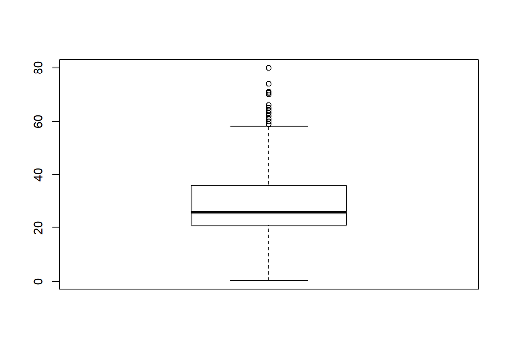

```r
bp <- boxplot(data$Age)
```

```r
bp$out
```

```
##  [1] 66.0 65.0 59.0 71.0 70.5 61.0 59.0 62.0 63.0 65.0 61.0 60.0 64.0 65.0 63.0
## [16] 71.0 64.0 62.0 62.0 60.0 61.0 80.0 70.0 60.0 60.0 70.0 62.0 74.0
```

Podemos observar en el gráfico que existen una serie de valores entre los 60 y 80 años que se desvían del centro de los datos. Sin embargo, no los consideraremos como outliers, simplemente consideraremos que entre los pasajeros hay un reducido número de gente mayor. Vamos a dividir este conjunto en tres grupos: child (edad inferior a 18), adult (edad igual o superior a 18 y menor de 60) y elder (más de 60 años) de cara a realizar futuros gráficos siguiendo esta agrupación

```r
ages <- cut(data$Age, breaks=c(-Inf, 18, 60,Inf), labels=c("child","adult", "elder"))
table(ages)
```

```
## ages
## child adult elder
##   160   709    22
```

# 4. Análisis de los datos

## 4.1 Selección de los grupos de datos que se quieren analizar/comparar

Llegados a este punto, el dataset contiene tres columnas que consideramos de interés para la resolución del problema planteado al inicio: clase, sexo y edad. Además estas, tenemos la el atributo target “Survived” que agrupa los pasajeros en fallecido o superviviente. En un primer lugar, veremos la relación que tiene el target (Survived) con el resto de atributos mediante gráficos de barras apiladas.

## 4.2. Comprobación de la normalidad y homogeneidad de la varianza.

En este apartado, vamos a comprobar la normalidad de los atributos de los que disponemos utilizando el test de Anderson-Darling existente en el paquete “nortest”. Debido a la naturaleza de los atributos Survived, Pclass y Sex, ya sabemos que no van a seguir una distribución normal, únicamente faltaría por comprobar Age.

```r
library(nortest)
cols <- c("Survived", "Pclass", "Age", "Sex")
a <- 0.05

for(col in cols){
    pvalue <- ad.test(as.numeric(data[,col]))$p.value
    if(pvalue < a){
      print(paste(col, "no cumple el test de normalidad"))
    } else{
      print(paste(col, "cumple el test de normalidad"))
    }
}
```

```
## [1] "Survived no cumple el test de normalidad"
## [1] "Pclass no cumple el test de normalidad"
## [1] "Age no cumple el test de normalidad"
## [1] "Sex no cumple el test de normalidad"
```

Al no superar el nivel de significancia de 0.05, se rechaza la hipótesis nula concluyendo que el atributo Age no sigue una distribución normal.

Ahora vamos a analizar la homogeneidad de las varianzas mediante la prueba de Prueba Brown-Forsythe para los campos “Survived” y “Pclass”

```r
library(onewaytests)
data2 = data.frame(Survived = data$Survived, Pclass =  data$Pclass)
data2$Survived <- as.numeric(data2$Survived)
bf.test(Survived ~ Pclass, data = data2)
```

```
##
##   Brown-Forsythe Test (alpha = 0.05)
## -------------------------------------------------------------
##   data : Survived and Pclass
##
##   statistic  : 53.02018
##   num df     : 2
##   denom df   : 559.3918
##   p.value    : 8.210571e-22
##
##   Result     : Difference is statistically significant.
## -------------------------------------------------------------
```

Dado que este test tampoco supera el nivel de significación de 0.05 concluímos que no posee la propiedad de homocedasticidad, y que el atributo Pclass presenta varianzas estadísticamente diferentes

#4.3 Aplicación de pruebas estadísticas para comparar los grupos de datos

En primer lugar vamos a ver de forma gráfica la distribución de cada atributo, por si se pudiese obtener alguna primera conclusión:

Supervivencia según la clase:

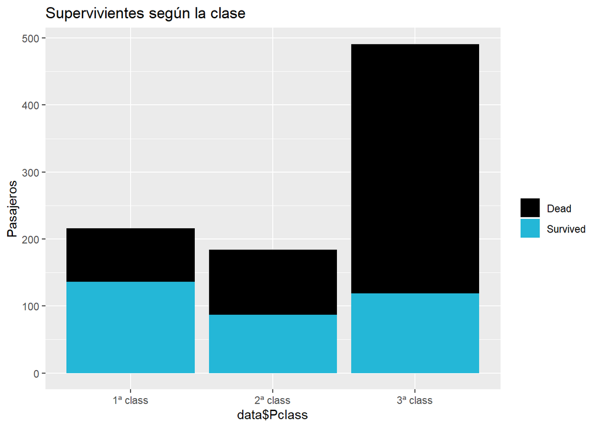

```r
library(ggplot2)
ggplot(data,aes(data$Pclass,fill=data$Survived))+geom_bar() +labs(y="Pasajeros")+ guides(fill=guide_legend(title=""))+ scale_fill_manual(values=c("black","#24B7D7"))+ggtitle("Supervivientes según la clase")
```

```r
tabla <- table(data$Pclass,data$Survived)
prop.table(tabla, margin = 1)
```

```
##
##                 Dead  Survived
##   1ª class 0.3703704 0.6296296
##   2ª class 0.5271739 0.4728261
##   3ª class 0.7576375 0.2423625
```

```r
table(data$Survived,data$Pclass)
```

```
##
##            1ª class 2ª class 3ª class
##   Dead           80       97      372
##   Survived      136       87      119
```

Como podemos observar en el gráfico y en la tabla, los pasajeros de tercera clase fallecieron en más de un 75% de los casos siendo esta clase donde se concentra la mayoría de los fallecidos: 372 fallecidos de un total de 549 (más del 67%). Los casos de supervivencia se elevan en segunda clase con respecto a la tercera, quedando unos resultados más parejos (52.71% fallecidos y 47.28% vivos), y se elevan aún más en primera clase, siendo la única clase que tiene más supervivientes que fallecidos.

Supervivencia según el sexo:

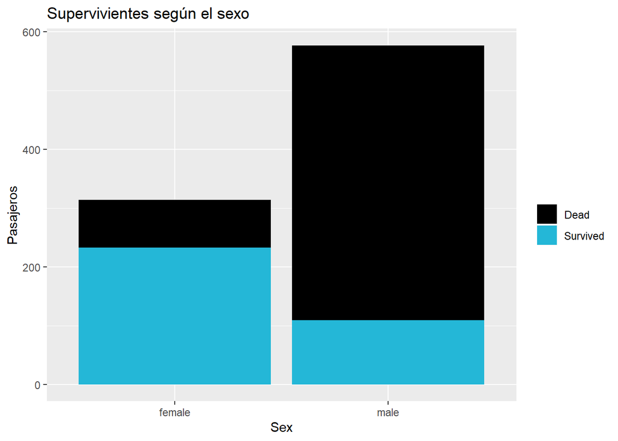

```r
ggplot(data,aes(Sex,fill=data$Survived))+geom_bar() +labs(y="Pasajeros")+ guides(fill=guide_legend(title=""))+ scale_fill_manual(values=c("black","#24B7D7"))+ggtitle("Supervivientes según el sexo")
```

```r
tabla <- table(data$Sex,data$Survived)
prop.table(tabla, margin = 1)
```

```
##
##               Dead  Survived
##   female 0.2579618 0.7420382
##   male   0.8110919 0.1889081
```

De este gráfico y tabla podemos conjeturar que según el sexo, las mujeres poseían una probabilidad de sobrevivir (74.2%) muy superior que los hombres (18.89%). Si a esto añadimos que había un mayor número de hombres, podemos ver que el grueso del número de fallecidos según sexo se encuentra en ellos.

Supervivencia según la edad:

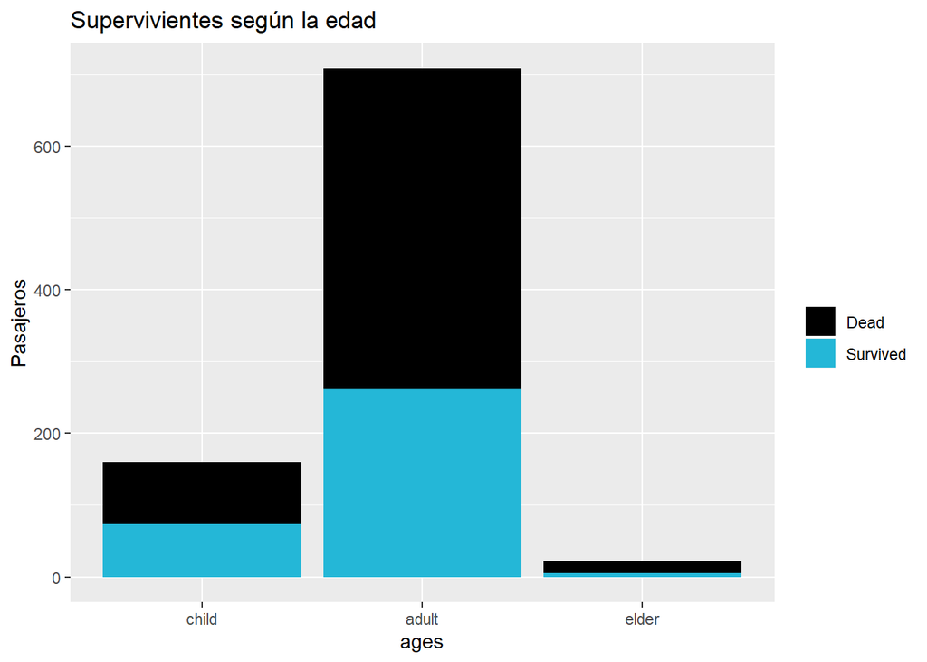

```r
ggplot(data,aes(ages,fill=data$Survived))+geom_bar() +labs(y="Pasajeros")+ guides(fill=guide_legend(title=""))+ scale_fill_manual(values=c("black","#24B7D7"))+ggtitle("Supervivientes según la edad")
```

```r
tabla <- table(ages,data$Survived)
prop.table(tabla, margin = 1)
```

```
##
## ages         Dead  Survived
##   child 0.5375000 0.4625000
##   adult 0.6290550 0.3709450
##   elder 0.7727273 0.2272727
```